# Exploratory Report: Juvenile Snowshoe Hares, 1998-2012

Alex Setmajer

11/8/2021

## Introduction

This report explores the counts and sizes of juvenile snowshoe hares recorded at the Bonanza Creek Experimental Forest in Alaska from 1998 - 2012. It includes summaries on annual juvenile hare counts, juvenile hare weights, and explores the relationship between juvenile weight and hind foot length.

## Data and Analysis

The Bonanza Creek LTER is part of the US Long Term Ecological Research (LTER) Network. Per the Metadata provided by the LTER team:

- weight (g)
- hindfoot length (mm)
- Site A (bonrip in original data set): Located in a flood zone along the Tanana River and Bonanza Mature is a mature black spruce forest approximately 1 km inland from the river and 2 km from the riparian plot.
- Site B (bonmat in original data set): Consisted of stands of mature white spruce, paper birch and alder, as well as black spruce and other plants.
- Site C (bonbs in original data set): Located in a mature lowland black spruce stand.

Data wrangling, analyses, and visualizations in this report are completed using R.

See the *Citations section* at the end of this report for data source citation.

## Juvenile Hare Initial Investigation

The following sections summarize data on Juvenile Snowshoe Hares based on the data provided from the LTER fieldwork. On average, data was collected quarterly each year.

An important data limitation to consider while reviewing the findings is that age data has only been provided for 1120 out of 3197 observations, or 35% of total observations. Additionally, age for observed hares did not begin being collected until June 1999, and there are significant gaps throughout the years of when age is reported. Of the observations with age data, there were only 378 juveniles counted (33.75% juveniles out of those with age data, or 11.82% of total observations).This means that this report focuses on a relatively small subset of the data collected.

### Part 1: Annual Juvenile Hare Trap Counts

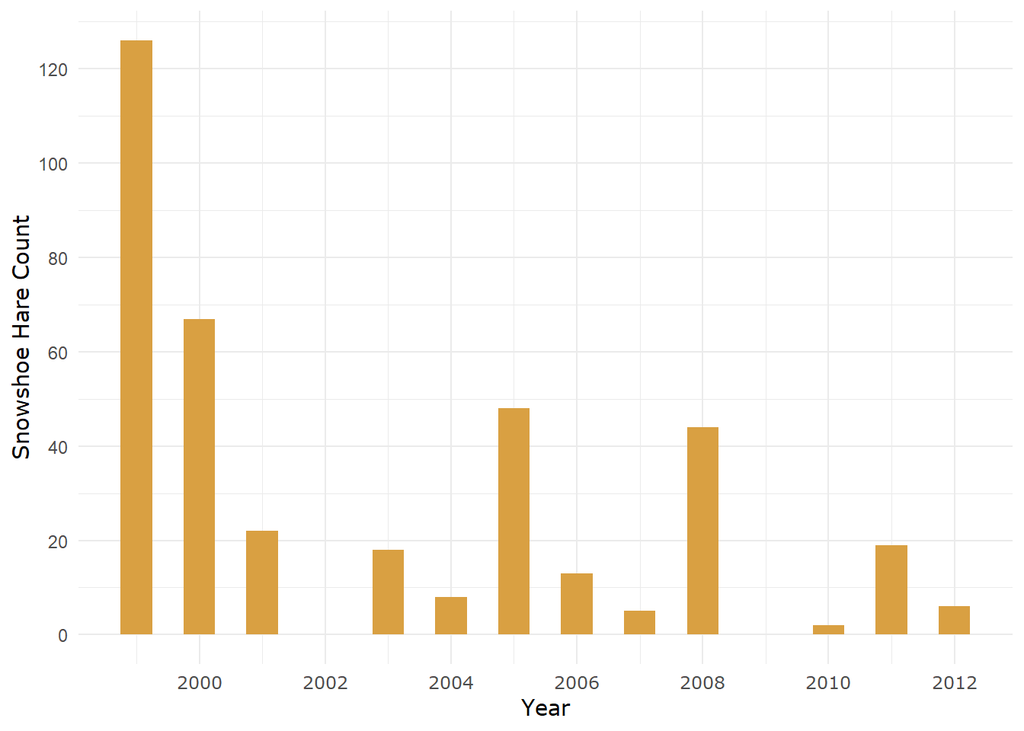

**Figure 1. Annual Juvenile Snowshoe Hare Trappings, 1998-2012.** This table provides a summary of the total juvenile Snowshoe Hares trapped annually between the years of 1998-2012.

The key takeaway from Figure 1 is that there appears to be an overall trend of decreasing juvenile hare counts. While some years counted more juveniles than others, as time went on, ‘high-count’ years were still significantly lower than juvenile counts in the first couple years of data collected. The minimum number of juveniles counted was 2 hares, the maximum number of juveniles was 126 hares. The mean count was approximately 32 juvenile hares, and the median was approximately 19 juvenile hares.

In order to standardize the juvenile hare population in future analyses, age data should be a required variable to provide for all observations of trapped hares. Using this data set as is, future analyses could be standardized by first meeting with data set owners to confirm that declining age trend seen in graph aligns with actual field conditions observed (confirming there was no other factor that limited the accurate collection of hare age). Then, using a linear regression or other model to create a formula that predicts the overall trend in juvenile hare counts with time.

### Part 2: Juvenile Hare Weights

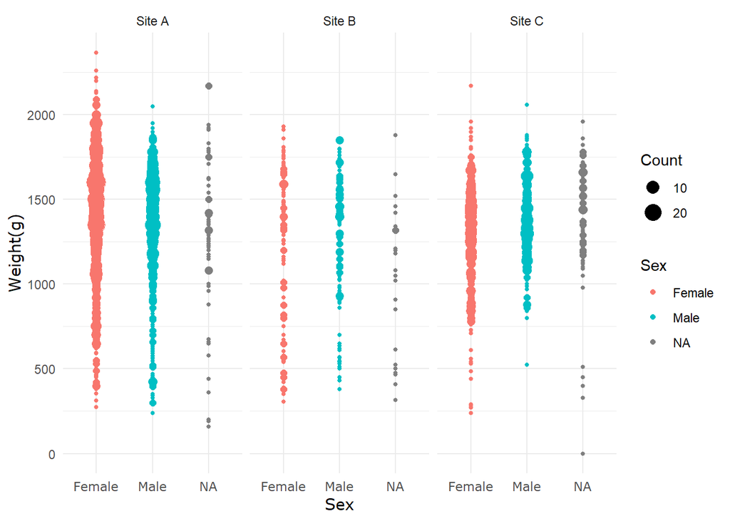

**Figure 2. Hare weights by sex and site.** This graph visually compares juvenile hare weights by sex and site. Variables where sex is not recorded are included in the graph in the N/A column.

Key takeaways from Figure 2 include the observation that the majority of juvenile hares across all ages range between approximately 750 and 1750 grams. Site A (Bonrip) had the most juvenile hares recorded. Overall, there appears to be a wider spread of female juvenile weights than male juvenile weights, especially at Site C (Bonbs).

### Part 3: Juvenile Weight Comparison

| Sex | Mean (g) | Std Deviation (g) | Sample Size (count) |
| --- | --- | --- | --- |
| Female | 1359.45 | 350.23 | 1450 |
| Male | 1348.13 | 310.26 | 1066 |

### Part 4: Relationship between Juvenile Weight & Hind Foot Length

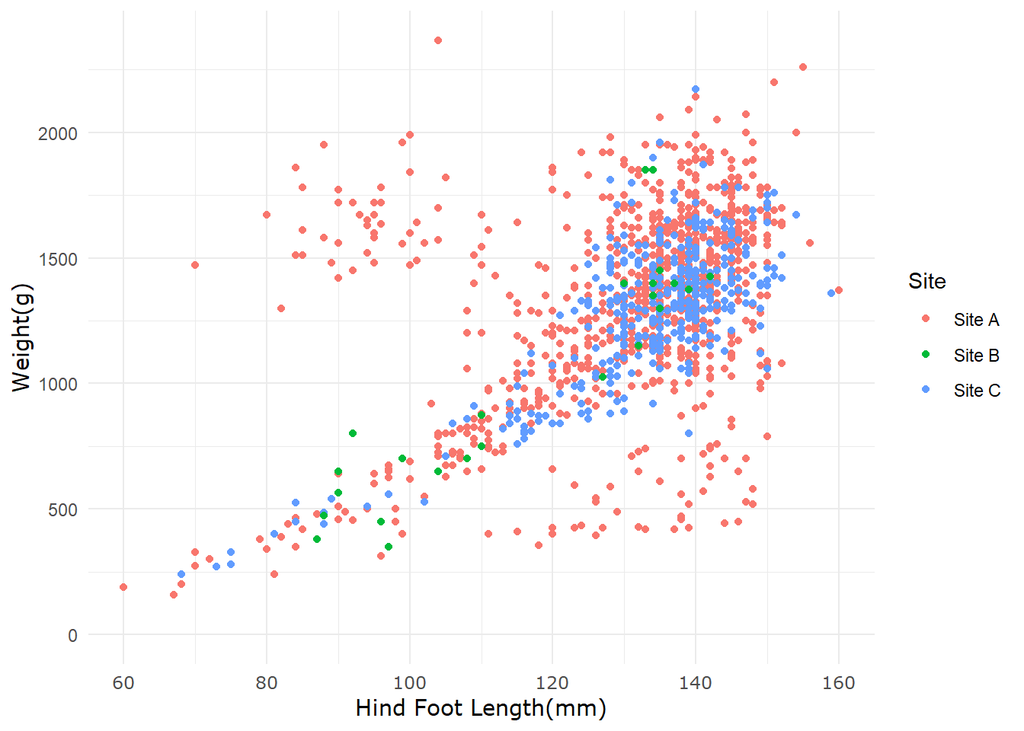

**Figure 3. Juvenile Hare Weight & Hind Foot Length.** This graph explores the relationship between juvenile snowshoe hare hind foot length(mm) and weight(g).

#### Linear Regression: Juvenile Hare Weight to Hind Foot Length

The slope of the linear regression comparing possible correlations between juvenile hare weight(g) and hind foot length(mm) is described by the following equation: weight(g) = 11.79(hind foot length(mm))-230.5

From this equation, we would gather that on average, we expect juvenile hare weight to increase by 11.79 grams for each 1 mm increase in hind foot length.

The R-squared value for this linear regression is 0.25, meaning that 25% of variance in hare weight can be explained by the hind foot length.

Pearson’s R for this linear regression is 0.5, indicating a medium positive correlation between the two variables.

Linear regressions assume residuals are normally distributed, however the residuals for this analysis appear to be negatively distributed (skewed to the right). This means that the model requires further investigation to determine that correlating hind foot length and weight is appropriate for juvenile Snowshoe Hares.

## Summary

Key findings from this exploratory report focused on Juvenile Snowshoe Hares are:

## Citations

Kielland, K., F.S. Chapin, R.W. Ruess, and Bonanza Creek LTER. 2017. Snowshoe hare physical data in Bonanza Creek Experimental Forest: 1999-Present ver 22. Environmental Data Initiative. https://doi.org/10.6073/pasta/03dce4856d79b91557d8e6ce2cbcdc14